# Basic Statistics in R

##### 1. Pearson Correlation

Pearson correlation is a statistic that measures linear correlation between two variables, given the assumption that the sample pairs are independent identically distributed and follow a bivariate normal distribution.

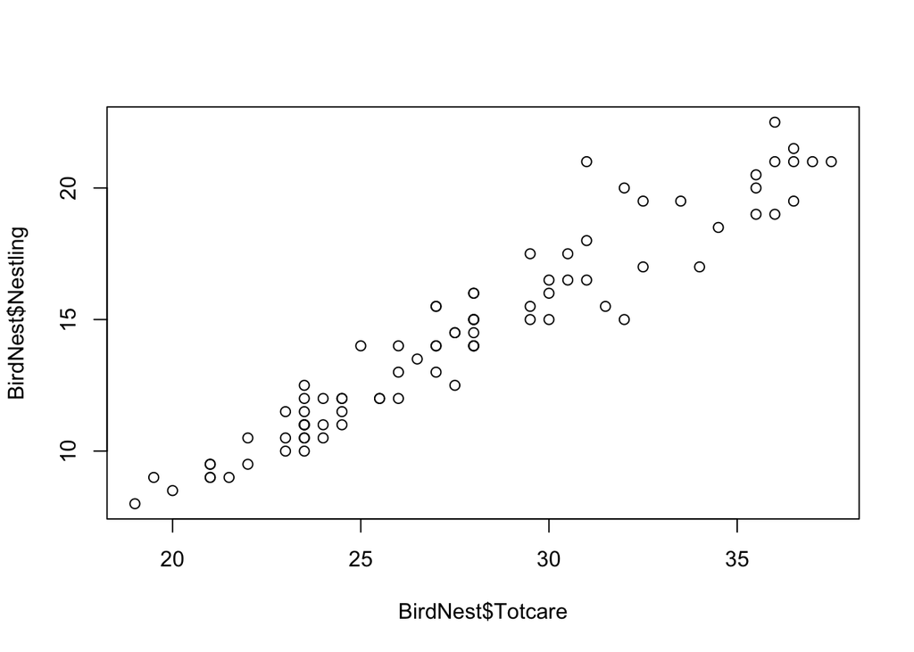

```r
library(Stat2Data)
data(BirdNest)
plot(BirdNest$Totcare, BirdNest$Nestling)
```

```r
cor.test(BirdNest$Totcare, BirdNest$Nestling, method = "pearson")
```

```
##
##  Pearson's product-moment correlation
##
## data:  BirdNest$Totcare and BirdNest$Nestling
## t = 30.603, df = 81, p-value < 2.2e-16
## alternative hypothesis: true correlation is not equal to 0
## 95 percent confidence interval:
##  0.9377250 0.9735995
## sample estimates:
##      cor
## 0.959374
```

##### 2. Spearman’s rank correlation coefficient

Spearman’s rank ’s correlation coefficient is a nonparametric measure of rank correlation (statistical dependence between the rankings of two variables). It assesses how well the relationship between two variables can be described using a monotonic function. (Wiki)

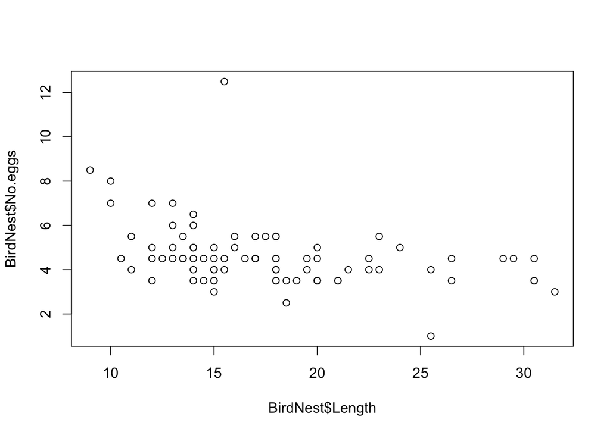

```r
plot(BirdNest$Length, BirdNest$No.eggs)
```

```r
cor.test(BirdNest$Length, BirdNest$No.eggs, method = "spearman", exact = F)
```

```
##
##  Spearman's rank correlation rho
##
## data:  BirdNest$Length and BirdNest$No.eggs
## S = 143033, p-value = 1.914e-05
## alternative hypothesis: true rho is not equal to 0
## sample estimates:
##        rho
## -0.4481381
```

##### 3. Cramer’s V

Cramer’s V is a measure of association between two nominal variables, returns a value between 0 and 1.

Recall that in the BirdNest data, egg color encoded as (0=plain/solid or 1=speckled/spotted) and closed encoded as 1=closed nest (pendant, spherical, cavity, crevice, burrow) or 0=open nest (saucer, cup).

```r
#install.packages("rcompanion")
library(rcompanion)
cramerV(BirdNest$Closed.,BirdNest$Color)
```

```
## Cramer V
##   0.0342
```

```r
cramerV(BirdNest$Closed.,BirdNest$Location)
```

```
## Cramer V
##   0.5842
```

```r
cramerV(BirdNest$Closed.,BirdNest$Nesttype)
```

```
## Cramer V
##        1
```

#### 4. Compare the means of two groups

Two sample t-test is a parametric test for comparing the means of two groups. The null hypothesis is the mean of two groups are equal. Alternative hypothesis is that they are not equal. Significance level is set to 0.05. The process of perform a t-test in R could be found at [source](http://www.sthda.com/english/wiki/unpaired-two-samples-t-test-in-r).

A useful source to look up statistical analysis about their assumption, interpretation and how to perform in different software is: http://rcompanion.org/rcompanion/b_07.html You may check out more about paired or unpaired t-test, comparing the means of more than two groups using Analysis of Variance (ANOVA) or nonparametric test for comparing means of two groups (Mann-Whitney U test) etc.

```r
library(dplyr)
t_test_data <-
  BirdNest %>% filter(Location  %in% c("ground", "shrub"))

group_by(t_test_data, Location) %>%
    summarise(
    count = n(),
    mean = mean(Totcare, na.rm = TRUE),
    sd = sd(Totcare, na.rm = TRUE)
  )
```

| Location | count | mean | sd |
| --- | --- | --- | --- |
| ground | 19 | 23.55263 | 2.919735 |
| shrub | 17 | 25.91176 | 4.089756 |

```r
#install.packages("ggpubr")
library(ggpubr)
```

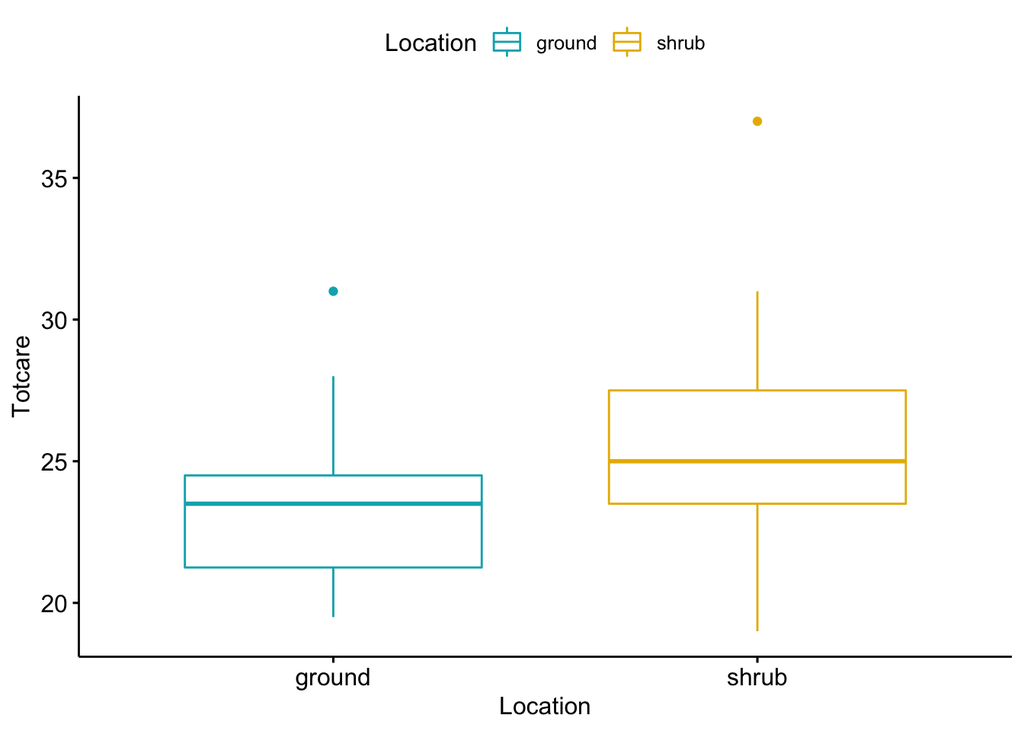

```r
ggboxplot(t_test_data, x = "Location", y = "Totcare",
          color = "Location", palette = c("#00AFBB", "#E7B800"),
        ylab = "Totcare", xlab = "Location")
```

```r
# Shapiro-Wilk normality test for shrub's Totcare
with(t_test_data, shapiro.test(Totcare[Location == "shrub"]))# p = 0.1556
```

```
##
##  Shapiro-Wilk normality test
##
## data:  Totcare[Location == "shrub"]
## W = 0.92135, p-value = 0.1556
```

```r
# Shapiro-Wilk normality test for ground's Totcare
with(t_test_data, shapiro.test(Totcare[Location == "ground"])) # p = 0.1502
```

```
##
##  Shapiro-Wilk normality test
##
## data:  Totcare[Location == "ground"]
## W = 0.92665, p-value = 0.1502
```

```r
#  F-test to test for homogeneity in variances
res.ftest <- var.test(Totcare ~ Location, data = t_test_data) # p = 0.1698
res.ftest
```

```
##
##  F test to compare two variances
##
## data:  Totcare by Location
## F = 0.50967, num df = 18, denom df = 16, p-value = 0.1698
## alternative hypothesis: true ratio of variances is not equal to 1
## 95 percent confidence interval:
##  0.1875867 1.3457175
## sample estimates:
## ratio of variances
##          0.5096736
```

```r
# t_test
res <- t.test(Totcare ~ Location, data = t_test_data, var.equal = TRUE)
res # p = 0.05264
```

```
##
##  Two Sample t-test
##
## data:  Totcare by Location
## t = -2.008, df = 34, p-value = 0.05264
## alternative hypothesis: true difference in means is not equal to 0
## 95 percent confidence interval:
##  -4.74673037  0.02846412
## sample estimates:
## mean in group ground  mean in group shrub
##             23.55263             25.91176
```

```r
res$conf.int
```

```
## [1] -4.74673037  0.02846412
## attr(,"conf.level")
## [1] 0.95
```

#### 5. Chi-square test

Chi-square test used for testing independence by evaluating the closeness between observed and expected frequencies.  
Assumption: large samples and independence of individual observation.

```r
library(rcompanion)
table <- data.frame(
  smoker=c("Yes","No","Yes","No"),
  lung_cancer=c("Cases","Cases","Control","Control"),
  count=c(688,21,650,59)
)

ctable <- xtabs(count ~ smoker + lung_cancer, data=table);ctable
```

```
##       lung_cancer
## smoker Cases Control
##    No     21      59
##    Yes   688     650
```

```r
chisq.test(ctable, correct = FALSE)
```

```
##
##  Pearson's Chi-squared test
##
## data:  ctable
## X-squared = 19.129, df = 1, p-value = 1.222e-05
```

#### 6. Fisher exact test

Fisher’s exact test can be used for test of independence when $n$ is small.  
Assumption: independence of individual observation and fixed totals. (the row and column totals are fixed, or “conditioned.”) When row or column totals are unconditioned, makes this test less powerful.

```r
tea <- matrix(c(3,1,1,3),ncol=2,byrow=TRUE)
dimnames(tea) <- list(PouringFirst=c("Milk","Tea"), GuessPouredFirst=c("Milk","Tea"))
tea
```

```
##             GuessPouredFirst
## PouringFirst Milk Tea
##         Milk    3   1
##         Tea     1   3
```

```r
fisher.test(tea, alternative = "greater") # set alternative to "greater", "less", "two.sided" for one-sided or two-sided test
```

```
##
##  Fisher's Exact Test for Count Data
##
## data:  tea
## p-value = 0.2429
## alternative hypothesis: true odds ratio is greater than 1
## 95 percent confidence interval:
##  0.3135693       Inf
## sample estimates:
## odds ratio
##   6.408309
```

#### 7. Linear regression

Linear regression explain the relationship between continuous response and predictors. A linear regression has an equation of the form $Y= X\beta + \epsilon$, where $X$ is the explanatory matrix with the first columns of all 1s (intercept) and $Y$ is the dependent variable. The standard multiple (linear) regression equation with p predictor variables and N observations $y_i$ = $b_0$ + $b_1 x_{i1}$ + $b_2 x_{i2}$ + … + $b_p x_{ip}$ + $\epsilon_{i}$, where $i$=$1,...,N.$  
The random errors $\epsilon$ are assumed to be independently and identically normally distributed.

Example: Hourly carbon monoxide (CO) averages were recorded on summer weekdays at a measurement station in Los Angeles. The data could be downloaded from [here](http://www.statsci.org/data/general/cofreewy.txt). There are four variables, which represents for：

| Variable | Description |
| --- | --- |
| Hour | hour of the day, from midnight to midnight |
| CO | average summer weekday CO concentration (parts per million) |
| Traffic | average weekday traffic density (traffic count/traffic speed) |
| Wind | average perpendicular wind-speed component, wind speed x cos(wind direction - 235 degrees) |

Use CO as depedent variable, the other three variables as predictor to build a linear regression model.

```r
lm_data <- read.table("http://www.statsci.org/data/general/cofreewy.txt", header = T)
head(lm_data)
```

|  | Hour | CO | Traffic | Wind |
| --- | --- | --- | --- | --- |
| 1 | 1 | 2.4 | 50 | -0.2 |
| 2 | 2 | 1.7 | 26 | 0.0 |
| 3 | 3 | 1.4 | 16 | 0.0 |
| 4 | 4 | 1.2 | 10 | 0.0 |
| 5 | 5 | 1.2 | 12 | 0.1 |
| 6 | 6 | 2.0 | 41 | -0.1 |

```r
lm.fit <- lm(CO~.,lm_data)
summary(lm.fit)
```

```
##
## Call:
## lm(formula = CO ~ ., data = lm_data)
##
## Residuals:
##      Min       1Q   Median       3Q      Max
## -0.75030 -0.33275 -0.09021  0.22653  1.25112
##
## Coefficients:
##              Estimate Std. Error t value Pr(>|t|)
## (Intercept)  1.318967   0.242522   5.439 2.53e-05 ***
## Hour        -0.005689   0.017066  -0.333  0.74233
## Traffic      0.018402   0.001413  13.026 3.15e-11 ***
## Wind         0.179189   0.059517   3.011  0.00691 **
## ---
## Signif. codes:  0 '***' 0.001 '**' 0.01 '*' 0.05 '.' 0.1 ' ' 1
##
## Residual standard error: 0.5096 on 20 degrees of freedom
## Multiple R-squared:  0.9498, Adjusted R-squared:  0.9423
## F-statistic: 126.1 on 3 and 20 DF,  p-value: 3.682e-13
```

```r
lm.step <- step(lm.fit, direction = "backward")
```

```
## Start:  AIC=-28.73
## CO ~ Hour + Traffic + Wind
##
##           Df Sum of Sq    RSS     AIC
## - Hour     1     0.029  5.224 -30.597
## <none>                  5.195 -28.730
## - Wind     1     2.354  7.549 -21.759
## - Traffic  1    44.070 49.265  23.260
##
## Step:  AIC=-30.6
## CO ~ Traffic + Wind
##
##           Df Sum of Sq    RSS     AIC
## <none>                  5.224 -30.597
## - Wind     1     2.357  7.581 -23.659
## - Traffic  1    46.117 51.341  22.250
```

```r
summary(lm.step)
```

```
##
## Call:
## lm(formula = CO ~ Traffic + Wind, data = lm_data)
##
## Residuals:
##      Min       1Q   Median       3Q      Max
## -0.72858 -0.31710 -0.09629  0.22409  1.26554
##
## Coefficients:
##             Estimate Std. Error t value Pr(>|t|)
## (Intercept) 1.274461   0.198137   6.432 2.25e-06 ***
## Traffic     0.018290   0.001343  13.616 6.85e-12 ***
## Wind        0.174747   0.056765   3.078   0.0057 **
## ---
## Signif. codes:  0 '***' 0.001 '**' 0.01 '*' 0.05 '.' 0.1 ' ' 1
##
## Residual standard error: 0.4987 on 21 degrees of freedom
## Multiple R-squared:  0.9495, Adjusted R-squared:  0.9447
## F-statistic: 197.5 on 2 and 21 DF,  p-value: 2.419e-14
```

```r
shapiro.test(lm.step$res)
```

```
##
##  Shapiro-Wilk normality test
##
## data:  lm.step$res
## W = 0.91918, p-value = 0.05601
```

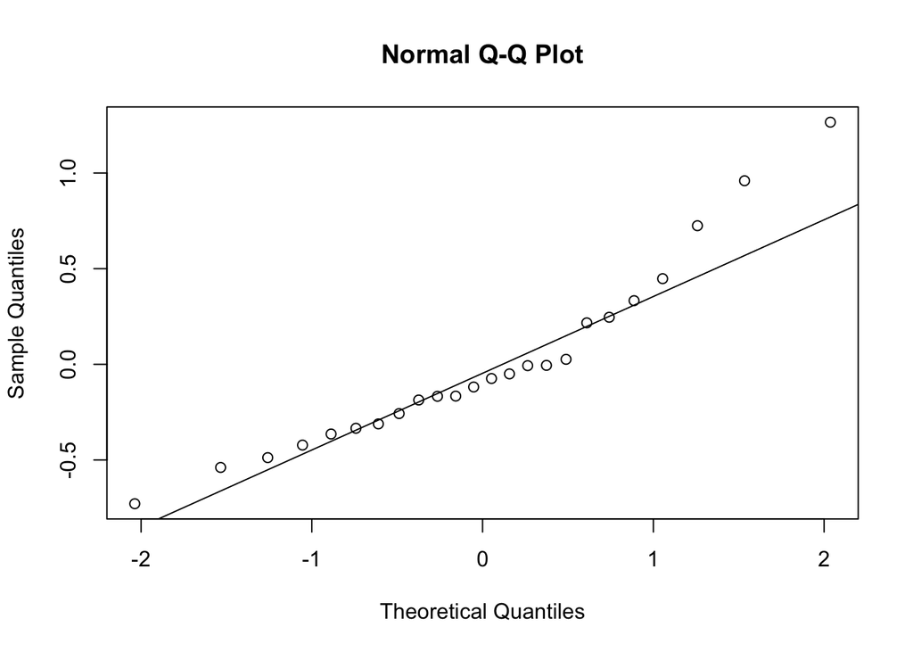

```r
qqnorm(lm.step$res);qqline(lm.step$res)
```

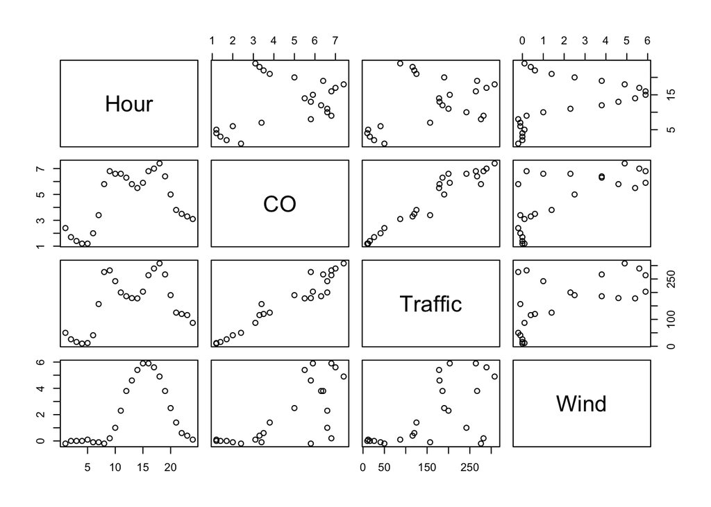

```r
plot(lm_data)
```

If you are interested in the linear regression example, read more about this analysis from the [source](http://www.statsci.org/data/general/cofreewy.html).

#### 8. Format data

“apa” and “apaTables” are helpful in formatting statistical results. You may review manual for the details of object applicable to the functions. Reference manual: [apa](https://cran.r-project.org/web/packages/apa/apa.pdf) and [apaTables](https://cran.r-project.org/web/packages/apaTables/vignettes/apaTables.html).

```r
#install.packages("apa")
#insatll.packcages("apaTables")
library(apa)
#apa(t.test(Totcare ~ Location, data = t_test_data, var.equal = TRUE), format = "docx") #format to docx
#apa(t.test(Totcare ~ Location, data = t_test_data, var.equal = TRUE), format = "latex") #format to latex

t_apa(t.test(Totcare ~ Location, data = t_test_data, var.equal = TRUE))
```

```
## t(34) = -2.01, p = .053, d = -0.67
```

```r
library(apaTables)
apa.reg.table(lm.step, filename = "Table1_APA.doc", table.number = 1)
```

```
##
##
## Table 1
##
## Regression results using CO as the criterion
##
##
##    Predictor      b     b_95%_CI beta  beta_95%_CI sr2  sr2_95%_CI     r
##  (Intercept) 1.27** [0.86, 1.69]
##      Traffic 0.02** [0.02, 0.02] 0.85 [0.72, 0.97] .45  [.18, .71] .96**
##         Wind 0.17** [0.06, 0.29] 0.19 [0.06, 0.32] .02 [-.01, .05] .71**
##
##
##
##              Fit
##
##
##
##      R2 = .950**
##  95% CI[.88,.97]
##
##
## Note. A significant b-weight indicates the beta-weight and semi-partial correlation are also significant.
## b represents unstandardized regression weights. beta indicates the standardized regression weights.
## sr2 represents the semi-partial correlation squared. r represents the zero-order correlation.
## Square brackets are used to enclose the lower and upper limits of a confidence interval.
## * indicates p < .05. ** indicates p < .01.
##
```

Use “table1” package to generate summary statistics. See other options in [Easily create descriptive summary statistics](http://thatdatatho.com/2018/08/20/easily-create-descriptive-summary-statistic-tables-r-studio/).

```r
#install.packages("table1")
library(table1)
table <- table1(~  Totcare + factor(Nesttype)  | Location, data=t_test_data);table
```

|  | ground (N=19) | shrub (N=17) | Overall (N=36) |
| --- | --- | --- | --- |
| Totcare |  |  |  |
| Mean (SD) | 23.6 (2.92) | 25.9 (4.09) | 24.7 (3.67) |
| Median [Min, Max] | 23.5 [19.5, 31.0] | 25.0 [19.0, 37.0] | 23.5 [19.0, 37.0] |
| factor(Nesttype) |  |  |  |
| crevice | 1 (5.3%) | 0 (0%) | 1 (2.8%) |
| cup | 16 (84.2%) | 15 (88.2%) | 31 (86.1%) |
| saucer | 2 (10.5%) | 0 (0%) | 2 (5.6%) |
| spherical | 0 (0%) | 2 (11.8%) | 2 (5.6%) |

Use “finalfit” package to generate summary statistics with association between dependent and independent variables.

```r
#install.packages("finalfit")
library(finalfit)
dependent = "differ.factor"

# Specify explanatory variables of interest
explanatory = c("age", "sex.factor",
  "extent.factor", "obstruct.factor",
  "nodes")

colon_s %>%
  summary_factorlist(dependent, explanatory,
  p=TRUE, na_include=TRUE)
```

```
## Note: dependent includes missing data. These are dropped.
```

| label | levels | Well | Moderate | Poor | p |
| --- | --- | --- | --- | --- | --- |
| Age (years) | Mean (SD) | 60.2 (12.8) | 59.9 (11.7) | 59.0 (12.8) | 0.644 |
| Sex | Female | 51 (54.8) | 314 (47.4) | 73 (48.7) | 0.400 |
|  | Male | 42 (45.2) | 349 (52.6) | 77 (51.3) |  |
| Extent of spread | Submucosa | 5 (5.4) | 12 (1.8) | 3 (2.0) | 0.081 |
|  | Muscle | 12 (12.9) | 78 (11.8) | 12 (8.0) |  |
|  | Serosa | 76 (81.7) | 542 (81.7) | 127 (84.7) |  |
|  | Adjacent structures | 0 (0.0) | 31 (4.7) | 8 (5.3) |  |
| Obstruction | No | 69 (74.2) | 531 (80.1) | 114 (76.0) | 0.655 |
|  | Yes | 19 (20.4) | 122 (18.4) | 31 (20.7) |  |
|  | (Missing) | 5 (5.4) | 10 (1.5) | 5 (3.3) |  |

[output cut: 1 more lines]

Reference: [Exporting tables and plots](https://cran.r-project.org/web/packages/finalfit/vignettes/export.html)